# AlwaysR, Módulo III: Estadística en R.

Lab 02

Giancarlo M. Correa

En esta sección se resume los conceptos más importantes vistos en la parte práctica de cada clase.

Cargamos librerías a utilizar

```r
library(ggplot2)
library(car)
library(Sleuth3)
library(MASS)
library(PairedData)
library(BSDA)
```

Bases de datos a utilizar:

```r
head(ex0222)
```

```
##   Gender Arith Word Parag Math AFQT
## 1   male    19   27    14   14 70.3
## 2 female    23   34    11   20 60.4
## 3   male    30   35    14   25 98.3
## 4 female    30   35    13   21 84.7
## 5 female    13   30    11   12 44.5
## 6 female     8   15     6    4  4.0
```

```r
head(Cars93)
```

```
##   Manufacturer   Model    Type Min.Price Price Max.Price MPG.city MPG.highway
## 1        Acura Integra   Small      12.9  15.9      18.8       25          31
## 2        Acura  Legend Midsize      29.2  33.9      38.7       18          25
## 3         Audi      90 Compact      25.9  29.1      32.3       20          26
## 4         Audi     100 Midsize      30.8  37.7      44.6       19          26
## 5          BMW    535i Midsize      23.7  30.0      36.2       22          30
## 6        Buick Century Midsize      14.2  15.7      17.3       22          31
##              AirBags DriveTrain Cylinders EngineSize Horsepower  RPM
## 1               None      Front         4        1.8        140 6300
## 2 Driver & Passenger      Front         6        3.2        200 5500
## 3        Driver only      Front         6        2.8        172 5500
## 4 Driver & Passenger      Front         6        2.8        172 5500
## 5        Driver only       Rear         4        3.5        208 5700
## 6        Driver only      Front         4        2.2        110 5200
##   Rev.per.mile Man.trans.avail Fuel.tank.capacity Passengers Length Wheelbase
## 1         2890             Yes               13.2          5    177       102
## 2         2335             Yes               18.0          5    195       115
## 3         2280             Yes               16.9          5    180       102
## 4         2535             Yes               21.1          6    193       106
## 5         2545             Yes               21.1          4    186       109
## 6         2565              No               16.4          6    189       105
##   Width Turn.circle Rear.seat.room Luggage.room Weight  Origin          Make
## 1    68          37           26.5           11   2705 non-USA Acura Integra
## 2    71          38           30.0           15   3560 non-USA  Acura Legend
## 3    67          37           28.0           14   3375 non-USA       Audi 90
## 4    70          37           31.0           17   3405 non-USA      Audi 100
## 5    69          39           27.0           13   3640 non-USA      BMW 535i
## 6    69          41           28.0           16   2880     USA Buick Century
```

```r
data(Rugby)
head(Rugby)
```

```
##    EXPERT.1 EXPERT.2 Actions
## 1       2.9      3.3      A1
## 3       1.0      1.8      A2
## 4       0.0      0.0      A3
## 5       9.5      8.9      A4
## 8       9.3      8.1      A5
## 11      2.6      8.0      A6
```

Si queremos saber que información contiene cada base de datos, podemos ver la ayuda de ellas mediante `?ex0222`.

## Caso 1

Asumamos que las variables `EXPERT.1` y `EXPERT.2` tienen distribución normal. Queremos hacer una prueba para saber si la media de los puntajes dados por el experto 1 es mayor a la media de los puntajes dado por el experto 2.

Definimos la hipótesis nula y alternativa:

- $H_0: \mu_1 \leq \mu_2$
- $H_A: \mu_1 > \mu_2$

También puede ser representada:

- $H_0: \delta \leq 0$
- $H_A: \delta > 0$

Donde $\delta = \mu_1 - \mu_2$

Usamos la función `t.test` para una prueba de dos muestras pareadas:

```r
t.test(x = Rugby$EXPERT.1, y = Rugby$EXPERT.2, paired = TRUE, mu = 0,
       alternative = 'greater')
```

```
##
##  Paired t-test
##
## data:  Rugby$EXPERT.1 and Rugby$EXPERT.2
## t = -1.9523, df = 92, p-value = 0.973
## alternative hypothesis: true mean difference is greater than 0
## 95 percent confidence interval:
##  -0.5573222        Inf
## sample estimates:
## mean difference
##      -0.3010753
```

Esto nos lleva a fallar en rechazar $H_0$, lo que quiere decir que la media de los puntajes del experto 1 es menor o igual a la media de los puntajes del experto 2.

Podemos observar la distribución de las variables `EXPERT.1` y `EXPERT.2`:

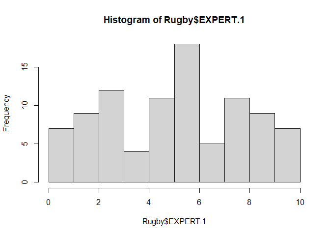

```r
hist(Rugby$EXPERT.1)
```

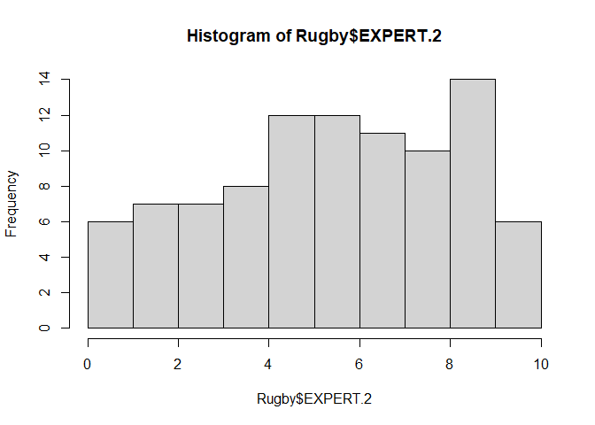

```r
hist(Rugby$EXPERT.2)
```

Parece que su distribución no es normal, por lo que una prueba `t.test` no puede ser válida. Podemos usar una prueba Wilcoxon Signed-Rank. Aquí:

- $H_0$: la distribución 1 es menor o igual a la distribución 2
- $H_A$: la distribución 1 es mayor a la distribución 2

Ejecutamos el test:

```r
wilcox.test(x = Rugby$EXPERT.1, y = Rugby$EXPERT.2, paired = TRUE, alternative = 'greater')
```

```
##
##  Wilcoxon signed rank test with continuity correction
##
## data:  Rugby$EXPERT.1 and Rugby$EXPERT.2
## V = 1406.5, p-value = 0.9676
## alternative hypothesis: true location shift is greater than 0
```

Como vemos, el $p-value$ es grande, por lo que nos lleva a fallar en rechazar la hipótesis nula.

## Caso 2

Deseamos hacer una prueba para saber si las variables `Origen` y `Man.trans.avail` de la base de datos `Cars93` están asociadas.

```r
myTable = table(Cars93$Origin, Cars93$Man.trans.avail)
print(myTable)
```

```
##
##           No Yes
##   USA     26  22
##   non-USA  6  39
```

Para esto, podemos aplicar una prueba Chi-cuadrado de Pearson:

- $H_0$: las variables son independientes entre ellas
- $H_A$: las variables no son independientes entre ellas

```r
chisq.test(x = myTable)
```

```
##
##  Pearson's Chi-squared test with Yates' continuity correction
##
## data:  myTable
## X-squared = 15.397, df = 1, p-value = 8.712e-05
```

Basado en el $p-value$, rechazamos la hipótesis nula y se concluye que las variables no son independientes, por lo que estan asociadas una con otra.

## Caso 3

Queremos evaluar si existen diferencias en el precio de vehículos (`Price`) en base al tipo de tracción (`DriveTrain`) de la base de datos `Cars93`.

Podemos hacer un ANOVA en este caso:

- $H_0$: el precio medio de cada tipo de tracción es igual
- $H_A$: existe algún tipo de tracción con precio medio diferente a los demás

```r
MyAnova = aov(Price ~ DriveTrain, data = Cars93)
summary(MyAnova)
```

```
##             Df Sum Sq Mean Sq F value  Pr(>F)
## DriveTrain   2   1722   861.1   11.29 4.2e-05 ***
## Residuals   90   6862    76.2
## ---
## Signif. codes:  0 '***' 0.001 '**' 0.01 '*' 0.05 '.' 0.1 ' ' 1
```

Basado en este resultado, rechazamos la hipótesis nula y se concluye que algún tipo de tracción tiene precio medio diferente a los demás.

Si queremos comparar por pares:

```r
TukeyHSD(x = MyAnova)
```

```
##   Tukey multiple comparisons of means
##     95% family-wise confidence level
##
## Fit: aov(formula = Price ~ DriveTrain, data = Cars93)
##
## $DriveTrain
##                  diff       lwr       upr     p adj
## Front-4WD  -0.0941791 -7.148353  6.959995 0.9994421
## Rear-4WD   11.3200000  2.931875 19.708125 0.0050886
## Rear-Front 11.4141791  5.624162 17.204197 0.0000278
```

Aquí podemos observar que existe una diferencia significativa entre `Rear` y `4WD`, y entre `Rear` y `Front`.

Sin embargo, también tenemos que revisar los supuestos más importantes del ANOVA:

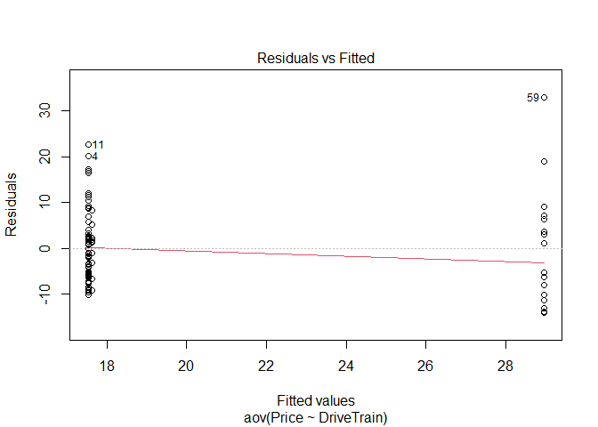

```r
plot(MyAnova, 1)
```

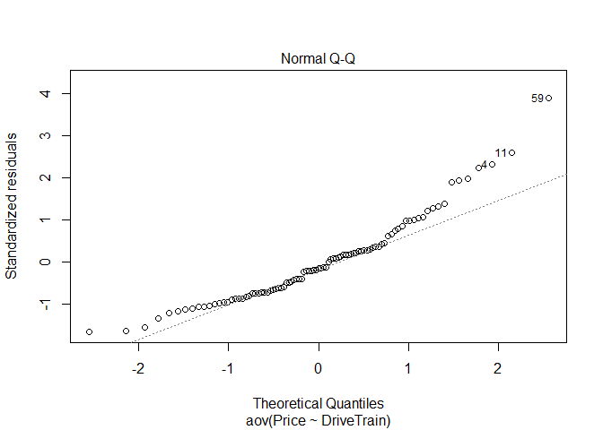

```r
plot(MyAnova, 2)
```

Basados en estos gráficos, al parece el supuesto de normalidad no se estaría cumpliendo.

## Caso 4

En este caso:

- $H_0: p \leq 0.75$
- $H_A: p>0.75$

Usamos una prueba binomial

```r
X = sum(Cars93$AirBags == 'Driver only')
n = nrow(Cars93)
binom.test(x = X, n = n, p = 0.75, alternative = 'greater')
```

```
##
##  Exact binomial test
##
## data:  X and n
## number of successes = 43, number of trials = 93, p-value = 1
## alternative hypothesis: true probability of success is greater than 0.75
## 95 percent confidence interval:
##  0.3738333 1.0000000
## sample estimates:
## probability of success
##              0.4623656
```